# Employment-to-Population Ratio Analysis

狄豪飛

2023-10-18

# Introduction

Employment-to-Population Ratio Analysis This analysis aims to explore the employment-to-population ratio dataset, focusing on various demographic groups and years.

## Boxplot: Employment-to-Population Ratios Across Age Groups

In this boxplot, each age group is represented on the x-axis, and the employment-to-population ratios are on the y-axis. This allows for a direct comparison of the distribution of employment-to-population ratios across age groups. It shows the median, quartiles, and potential outliers for each age group.

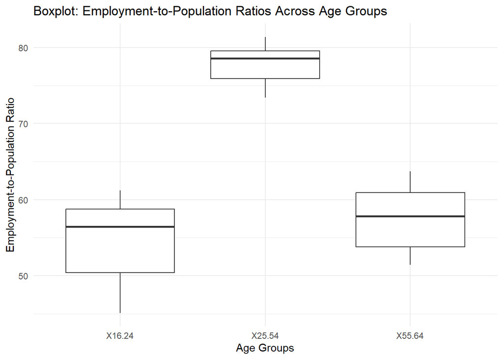

```r
# Create a boxplot for the employment-to-population ratios across different age groups
df_melted <- melt(df, id.vars = "year", measure.vars = c("X16.24", "X25.54", "X55.64"))

ggplot(df_melted, aes(x = variable, y = value)) +
  geom_boxplot() +
  ggtitle("Boxplot: Employment-to-Population Ratios Across Age Groups") +
  xlab("Age Groups") +
  ylab("Employment-to-Population Ratio") +
  theme_minimal()
```

[figure not shown]

```r
# Calculate the means for the specific columns
age_means <- colMeans(df[, c("X16.24", "X25.54", "X55.64", "X65.")])  # Replace these with your exact column names

# Convert to data frame for ggplot
age_means_df <- as.data.frame(t(age_means))
colnames(age_means_df) <- c("mean_ratio")
age_means_df$age_group <- rownames(age_means_df)

# Create enhanced bar plot
ggplot(age_means_df, aes(x = age_group, y = mean_ratio, fill = age_group)) +
  geom_bar(stat = "identity") +
  geom_text(aes(label = round(mean_ratio, 2)), vjust = -0.5) +
  scale_fill_brewer(palette = "Set1") +
  theme_minimal() +
  ggtitle("Enhanced Bar Plot: Average Employment-to-Population Ratio by Age Group") +
  xlab("Age Group") +
  ylab("Average Employment-to-Population Ratio")
```

## Scatter Plot: Year vs Total Population

The scatter plot shows how the total population has changed over the years.

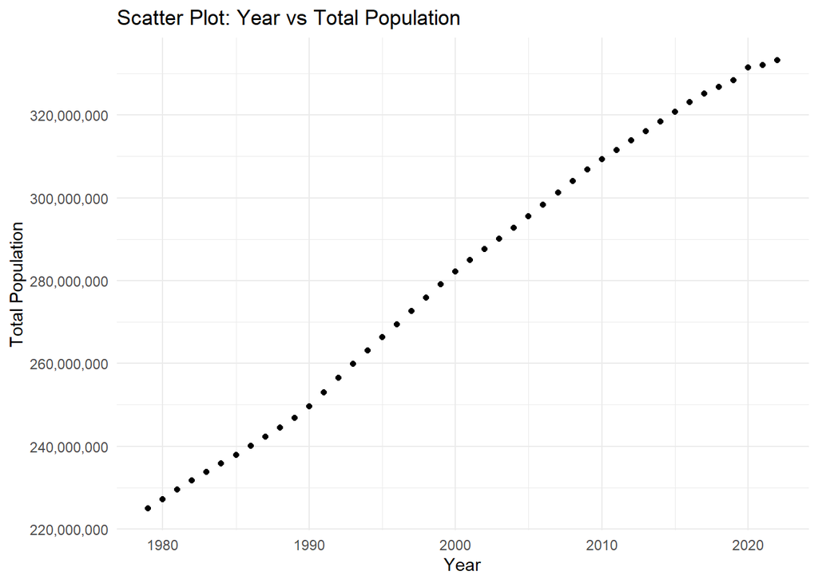

```r
# Create scatter plot with improved y-axis labels
ggplot(df, aes(x = year, y = total_population)) +
  geom_point() +
  scale_y_continuous(labels = scales::comma) +
  ggtitle("Scatter Plot: Year vs Total Population") +
  xlab("Year") +
  ylab("Total Population") +
  theme_minimal()
```

## QQ Plot: Employment-to-Population Ratio (Age 25-54)

The QQ plot is used to check for normality in the employment-to-population ratio for the age group 25-54.

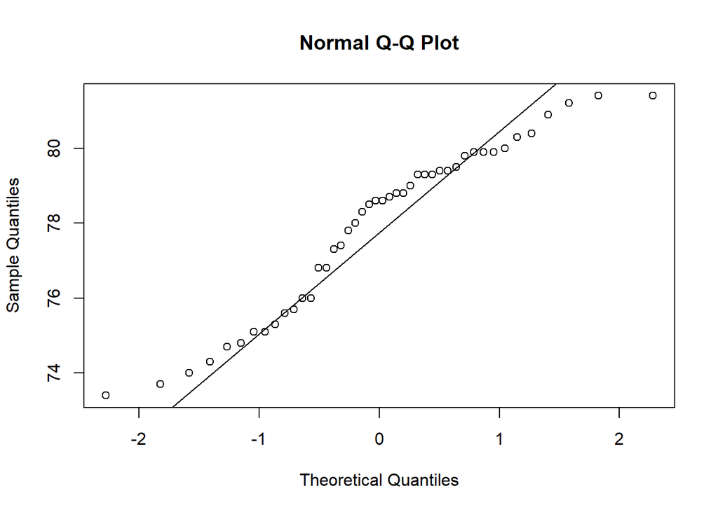

```r
qqnorm(df$"X25.54")
qqline(df$"X25.54")
```

## Density Plot: Employment-to-Population Ratio (Less than High School)

The density plot shows the distribution shape of the employment-to-population ratio for those with less than a high school education.

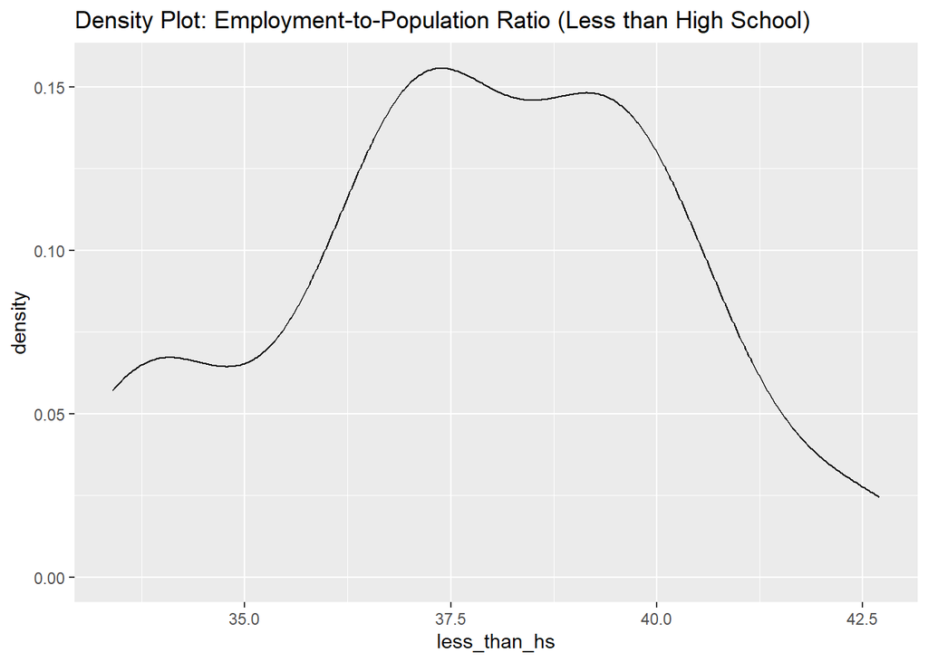

```r
ggplot(df, aes(x = less_than_hs)) +
  geom_density() +
  ggtitle("Density Plot: Employment-to-Population Ratio (Less than High School)")
```

## Pie Chart: Mean Employment-to-Population Ratio by Education Level

The pie chart provides a quick overview of the mean employment-to-population ratio across different levels of education.

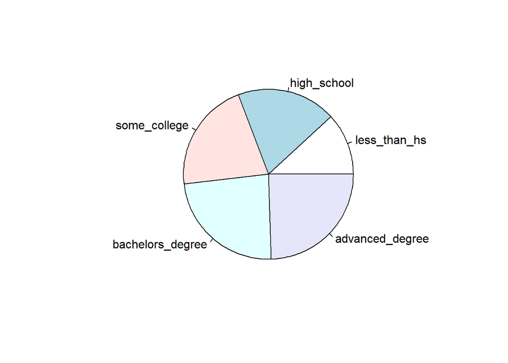

```r
education_means <- colMeans(df[, c("less_than_hs", "high_school", "some_college", "bachelors_degree", "advanced_degree")])
pie(education_means, labels = names(education_means))
```

## Histogram: Employment-to-Population Ratio (Bachelor’s Degree)

The histogram helps us understand the variability in employment ratios for those with a bachelor’s degree.

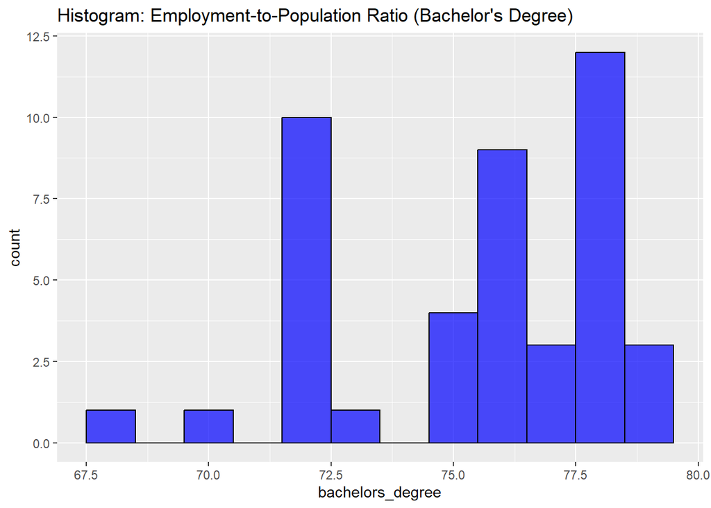

```r
ggplot(df, aes(x = bachelors_degree)) +
  geom_histogram(binwidth = 1, fill = "blue", alpha = 0.7, color = "black") +
  ggtitle("Histogram: Employment-to-Population Ratio (Bachelor's Degree)")
```

# Identifying Simpson’s Paradox in Employment-to-Population Ratio Data

## Simpson’s Paradox

Simpson’s Paradox is a statistical phenomenon where a trend seen in different groups of data disappears or reverses when the groups are combined. We will investigate whether this paradox exists in our dataset.

Overall Trend: Year vs Employment-to-Population Ratio (All Ages) First, let’s examine the overall trend in the data

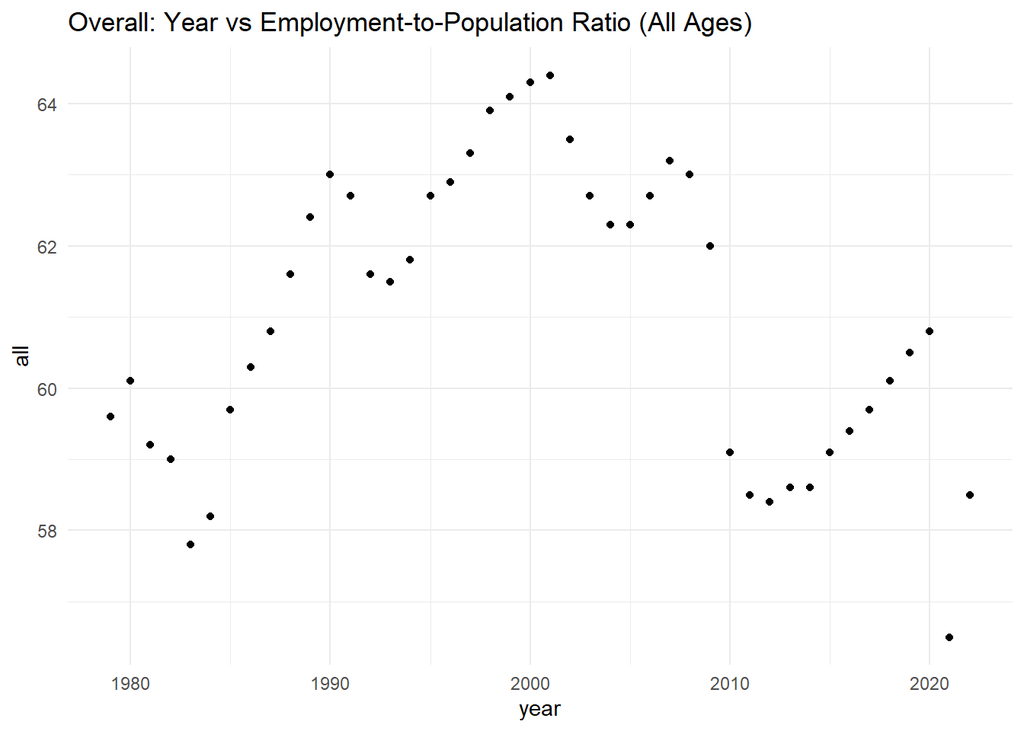

```r
ggplot(df, aes(x = year, y = all)) +
  geom_point() +
  ggtitle("Overall: Year vs Employment-to-Population Ratio (All Ages)") +
  theme_minimal()
```

## Year vs Employment-to-Population Ratio (Age 16-24)

Now let’s look at the trend for the age group 16-24.

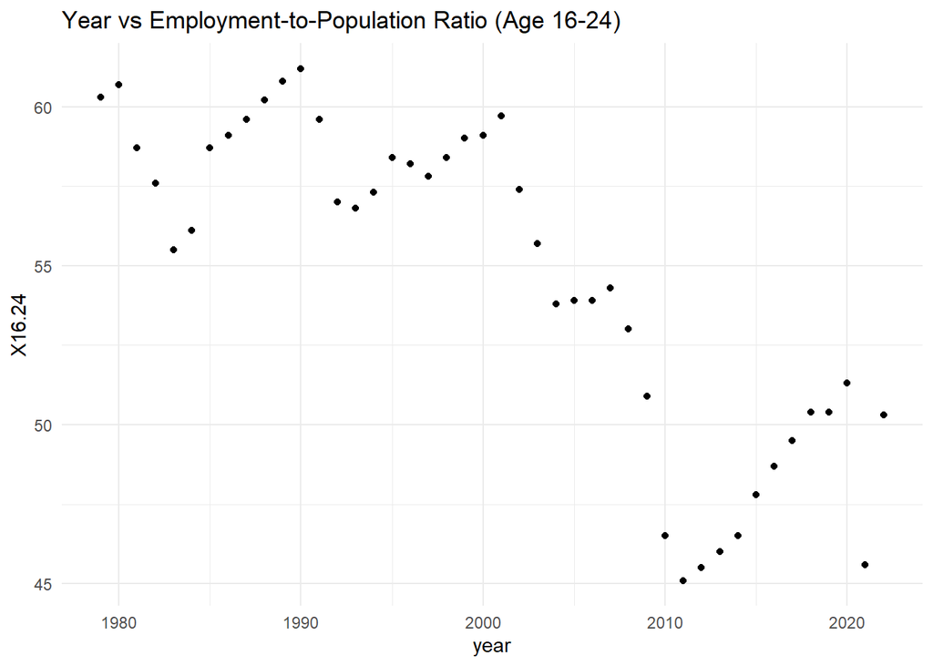

```r
ggplot(df, aes(x = year, y = `X16.24`)) +
  geom_point() +
  ggtitle("Year vs Employment-to-Population Ratio (Age 16-24)") +
  theme_minimal()
```

## Year vs Employment-to-Population Ratio (Age 25-54)

Next, we look at the age group 25-54.

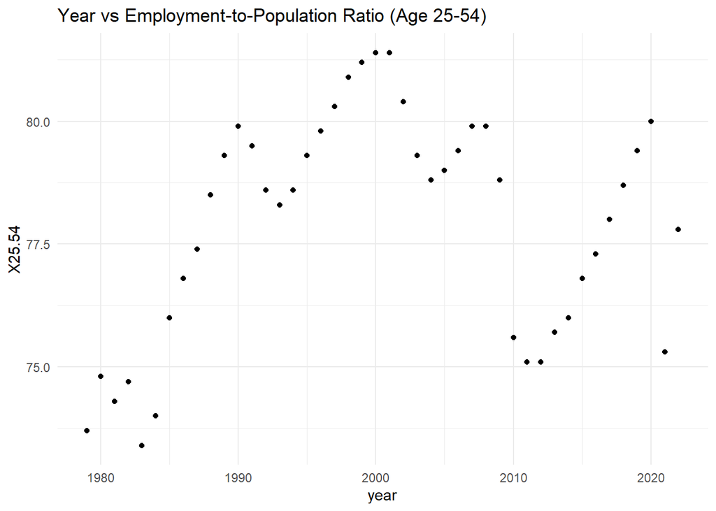

```r
ggplot(df, aes(x = year, y = `X25.54`)) +
  geom_point() +
  ggtitle("Year vs Employment-to-Population Ratio (Age 25-54)") +
  theme_minimal()
```

# Summary

## Final Overlay Plot

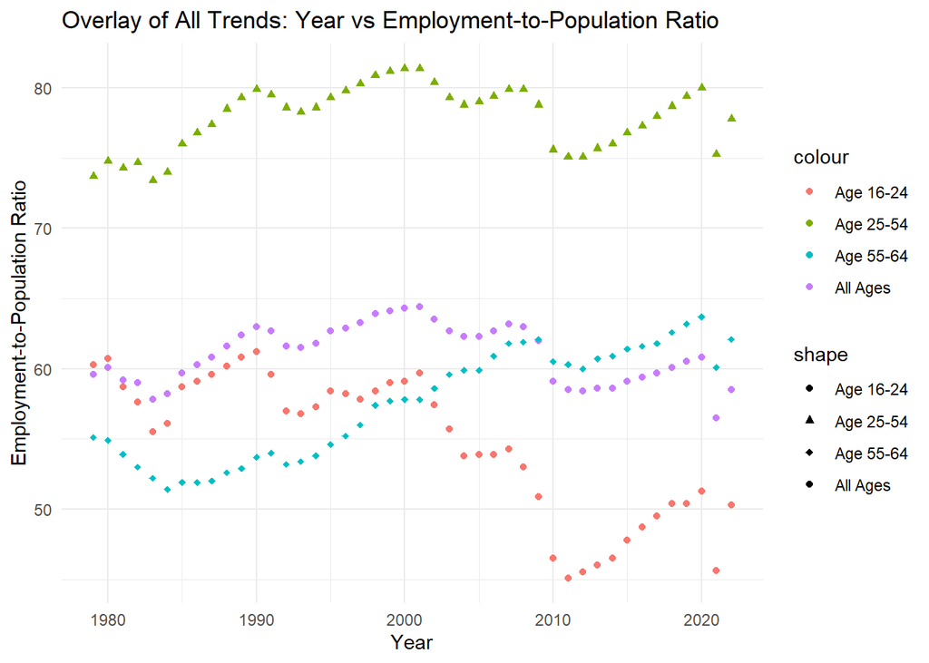

```r
# Create an overlay plot with different colors and shapes for each age group
ggplot(df, aes(x = year)) +
  geom_point(aes(y = all, color = "All Ages", shape = "All Ages")) +
  geom_point(aes(y = `X16.24`, color = "Age 16-24", shape = "Age 16-24")) +
  geom_point(aes(y = `X25.54`, color = "Age 25-54", shape = "Age 25-54")) +
  geom_point(aes(y = `X55.64`, color = "Age 55-64", shape = "Age 55-64")) +
  scale_shape_manual(values=c(16, 17, 18, 19)) +
  ggtitle("Overlay of All Trends: Year vs Employment-to-Population Ratio") +
  ylab("Employment-to-Population Ratio") +
  xlab("Year") +
  theme_minimal()
```

# Discuss possible problems you plan to investigate for future studies

Having learned about Simpson’s paradox, I thought I could use it in the analysis of the world’s best universities dataset that I discussed in Task 1 to: - Break down the rankings by academic departments or faculties within each university this will be useful to me in solving the following problem: Does a highly ranked university overall have a uniformly high departmental ranking? - This will be useful for the following problem: Is the overall ranking of a university influenced by its location?